# **Lab 6: Creating Figures in R**

Biostatistics 203A

November 21, 2023

In this lab, you will practice creating a variety of basic plots in R. You will learn how to customize these plots and to make them more visually appealing. In the coming weeks, you will learn how to use more advanced techniques for plotting, but the techniques presented in today’s lab will be useful for basic plotting needs.

A separate file containing your name, your UID number, and your responses to each of the items below labeled Exercise should be submitted to BruinLearn prior to 5:00PM on November 28th. This file will be graded on a scale from 0-20 and will count toward the homework component of your course grade.

## The `sas7bdat` Package

In today’s lab, we will be using the **drug_overdoses.sas7bdat** data set with contains the provisional death overdose death counts reported as part of the Vital Statistics Rapid Release (VSRR) by the CDC National Center for Health Statistics. Statistics are reported by state for 17 states and Washington DC.

While we could export the data set from SAS to a csv file and then read the data in to R using a command such as `read.csv`, there is an easier way. You can simply download the `sas7bdat` package.

```
install.packages("sas7bdat")
```

```r
library("sas7bdat")
```

You can then read the data in to R following the same approach as used with the `read.table` family of functions.

```r
ods <- read.sas7bdat("drug_overdoses.sas7bdat")
```

Each record in the `ods` data set is unique with respect to `STATE`, `YEAR`, and `MONTH` and contains the number of deaths in that given state, year, and month overall and deaths that can be attributed to a variety of different drugs. Here are the drug death variables:

- `NUMBER_DEATHS`
- `NUMBER_DRUG_OVERDOSE_DEATHS`
- `NUMBER_COCAINE_DEATHS`
- `NUMBER_HEROIN_DEATHS`
- `NUMBER_METHADONE_DEATHS`
- `NUMBER_NATURAL_OPIOD_DEATHS`
- `NUMBER_OPIOD_DEATHS`
- `NUMBER_PSYCHOSTIMULANT_DEATHS`
- `NUMBER_SYNTHETIC_OPIOD_DEATHS`

The `NUMBER_DEATHS` variable conatins all-cause mortality counts and is included in this data set to be used in evaluating relative changes in overdose death counts over time or between locations, while controlling for any fluctuations in all-cause mortality that may occur across time or region.

```r
head(ods)
```

## The Plot Function

The `plot` function is used to create basic figures in R. There are more advanced plotting packages that we will discuss later in this course, but the `plot` function can be easily used to create a variety of widely-used figure formats using relatively straightforward commands and without requiring the download of additional packages.

Using the `ods` data set (drug overdoses), let’s start by creating the simplest plot:

```r
plot(ods$YEAR)
```

If you provide the `plot` function with a single vector as an argument, it plots the values contained in that vector on the y-axis and the index (location) within the vector on the x-axis. To see this, let’s sort our data set according to the variable `YEAR` and replot the vector containing this variable.

```r
ods <- ods[order(ods$YEAR),]

plot(ods$YEAR)
```

Since we will be interested in plotting trends over time, let’s use what we have learned previously to create a `DATA_DATE` variable by combining information from the `YEAR` and `MONTH` variables.

```r
ods$DATA_DATE <- as.Date(paste(ods$YEAR, ods$MONTH, "01", sep="/"),format='%Y/%B/%d')
```

It’s more common to provide two vectors as the first two arguments of the `plot` function, corresponding to the two-dimensional plotting of data. In this instance, the first vector provides values to be plotted along the *x-axis* and the second argument provides values to be plotted along the *y-axis*.

Let’s attempt to plot the Number of Drug Overdose Deaths per month in New York from 2015-2018.

We will first create a data set containing only the death statistics for the state of New York.

```r
ny <- ods[ods$STATE == "NY",]

ny <- ny[order(ny$DATA_DATE),]
```

We can then call our `plot` function with two arguments:

```r
plot(ny$DATA_DATE, ny$NUMBER_DRUG_OVERDOSE_DEATHS)
```

Let’s experiment with different arguments that can be used to modify the appearance of your plot. First, let’s insert a main title and axis labels. We will also specify that the plotting symbols be blue instead of the default color of black.

```r
plot(ny$DATA_DATE, ny$NUMBER_DRUG_OVERDOSE_DEATHS,
     main = "Drug Overdose Deaths per Month\nNew York",
     xlab = "Year",
     ylab = "Number of Drug Overdose Deaths",
     col  = "blue")
```

R accepts a wide range of different text color names. A good reference for the many options can be found at http://www.stat.columbia.edu/~tzheng/files/Rcolor.pdf. The `\n` symbol within any quoted text instructs R to proceed to the next line (carriage return).

Next, let’s experiment with different plot types that can be requested using the `type` argument. The `plot` function help page gives us basic descriptions of the types of plots we can request:

`type` what type of plot should be drawn. Possible types are

- `p` for points
- `l` for lines
- `b` for both
- `c` for the lines part alone of `b`
- `o` for both *overplotted*
- `h` for *histogram-like* (or *high-density*) vertical lines
- `s` for stair steps
- `S` for other steps, see *Details*
- `n` for no plotting

Try out a couple of these plot types by executing code such as the following and changing the value of `type`:

```r
plot(ny$DATA_DATE, ny$NUMBER_DRUG_OVERDOSE_DEATHS,
     type = "l",
     main = "Drug Overdose Deaths per Month\nNew York",
     xlab = "Year",
     ylab = "Number of Drug Overdose Deaths",
     col  = "red")
```

What if we wanted to plot two separate lines on the same plot, one for Cocaine deaths and one for Heroin deaths in New York? We can simply execute a `lines` function after the `plot` function. Here we specify that the Heroin line be a different color and a different line type (`lty`) so that we can distinguish between the two lines.

```r
plot(ny$DATA_DATE, ny$NUMBER_COCAINE_DEATHS,
     type = "l",
     main = "Cocaine and Heroin Overdose Deaths per Month\nNew York",
     xlab = "Year",
     ylab = "Number of Drug Overdose Deaths",
     col  = "red")

lines(ny$DATA_DATE, ny$NUMBER_HEROIN_DEATHS, type="l", lty=2, col="blue")
```

By default, R determines the range for the x- and y-axes based on the data provided when the plot is first rendered. If additional lines are added subsequently, the default range may no longer be appropriate. The axis ranges can be specified explicitly through arguments provided to the `plot` function. For instance, if we would like the y-axis to extend from 250 to 850 (the full range of the number of deaths being plotted) we could add the argument

```
ylim = c(250,850)
```

A similar option is available for the x-axis (using argument `xlim`).

```r
plot(ny$DATA_DATE, ny$NUMBER_COCAINE_DEATHS,
     type = "l",
     main = "Cocaine and Heroin Overdose Deaths per Month\nNew York",
     xlab = "Year",
     ylim = c(250,850),
     ylab = "Number of Drug Overdose Deaths",
     col  = "red")

lines(ny$DATA_DATE, ny$NUMBER_HEROIN_DEATHS, type="l", lty=2, col="blue")
```

An example of different line type options are the following. They can be specified using either the number or the word shown below.

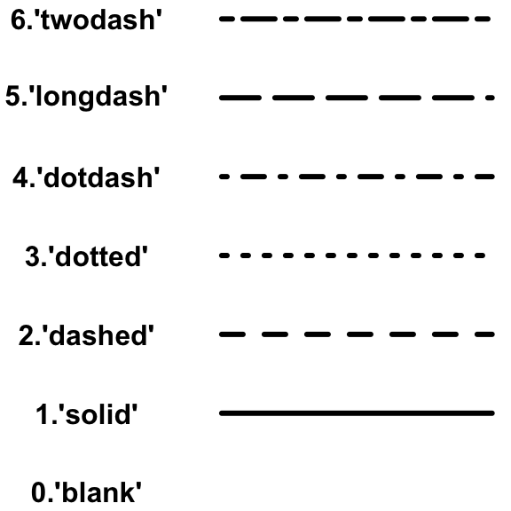

For example,

```
lines(ny$DATA_DATE, ny$NUMBER_HEROIN_DEATHS, type="l", lty='dashed', col="blue")
```

will produce the same result.

As was demonstrated with the addition of lines in a subsequent function, once a plot has been created using a `plot` function, it is not overridden by the addition of new functions such as `lines`. A plot will be overwritten when a new `plot` function is executed. In which case, that new plot will become the active plot to which lines and other attributes can be added.

```r
plot(ny$DATA_DATE, ny$NUMBER_COCAINE_DEATHS,
     type = "l",
     main = "Cocaine and Heroin Overdose Deaths per Month\nNew York",
     xlab = "Year",
     ylim = c(250,850),
     ylab = "Number of Drug Overdose Deaths",
     col  = "red")

lines(ny$DATA_DATE, ny$NUMBER_HEROIN_DEATHS, type="l", lty=2, col="blue")

legend(as.Date("01/01/2017", format="%m/%d/%Y"), 350,
        legend = c("Cocaine","Heroin"),
        col=c("red","blue"),
        lty=1:2)
```

The first two arguments to the `legend` function specify the respective x- and y-coordinates where the legend should be placed. The third argument (`legend`) indicates which names should be placed in the legend. The `col` and `lty` arguments express the color and line types corresponding to the different entries in the legend and will typically match the specifications you provided in the previous `plot` and `lines` commands.

**Exercise 1**

Using the `plot` function, write the R code necessary to recreate the plot below:

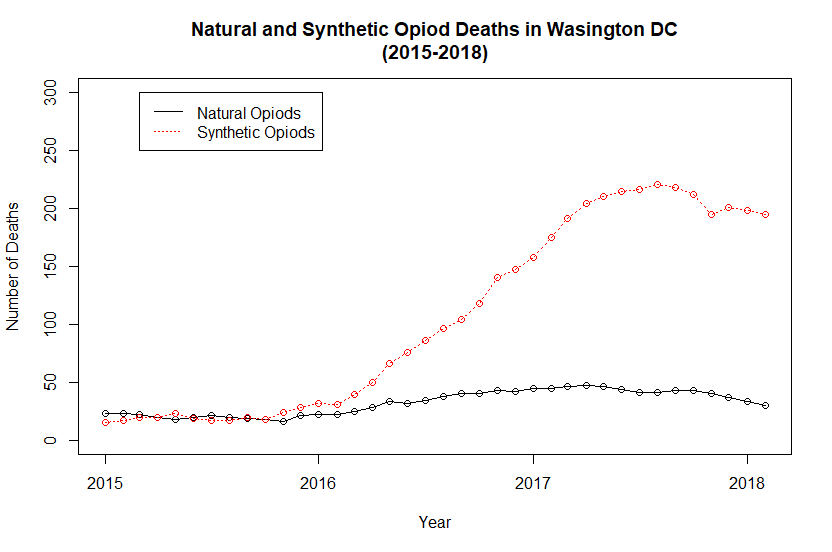

Copy and paste the code you used to complete this exercise into the file you submit along with the generated plot.

R also allows you to use different plotting symbols, which are specified using the argument `pch`. For example,

```r
plot(ny$DATA_DATE, ny$NUMBER_COCAINE_DEATHS,
     type = "p",
     pch = 18,
     main = "Cocaine Overdose Deaths per Month\nNew York",
     xlab = "Year",
     ylab = "Number of Drug Overdose Deaths")
```

## Plotting a Continuous and a Categorical Variable

Instead of plotting two continuous variables, we are often times interested in plotting a continuous variable and a categorical variable. For instance, imagine we would like to plot the average monthly overdose deaths by state for states in New England. We could start by creating a table containing this information.

```r
neweng <- droplevels(ods[ods$STATE %in% c('CT','ME','VT','NH','MA','RI'),])

nodne <- tapply(neweng$NUMBER_DRUG_OVERDOSE_DEATHS,
                 neweng$STATE,
                 mean, na.rm=T)
nodne
```

Try running the code above with and without the `droplevels` function. Can you explain why the results differ?

Information about the `droplevels` function can be found here:

https://stat.ethz.ch/R-manual/R-devel/library/base/html/droplevels.html

Next, we can plot the table directly which will plot the 5 values according to index:

```r
plot(nodne)
```

Although this does depict the information we are interested in, it is not very interpretable. To improve presentation, we will take a different approach. Let’s start with as simple a plot as possible and then add features such as axes and titles one at a time.

Plot the data in `nodtab` but exclude all axes and annotations

```r
plot(nodne,
      type = "o",
      pch = 16,
      axes = FALSE,
      ann = FALSE)
```

Next, add the x- and y-axes (`1` refers to the x-axis and `2` refers to the y-axis)

```r
plot(nodne,
      type = "o",
      pch = 16,
      axes = FALSE,
      ann = FALSE)

axis(1, at=1:5, lab = names(nodne))
axis(2)
```

Add a box around the entire plotting region, a main title, and x- and y-axis labels

```r
plot(nodne,
      type = "o",
      pch = 16,
      axes = FALSE,
      ann = FALSE)

axis(1, at=1:5, lab = names(nodne))
axis(2)

box()

title (main = "Average Monthly Count of Overdose Deaths by State", col.lab = "black")
title (ylab = "Average Monthly Count of Overdose Deaths", col.lab = "darkturquoise")
title (xlab = "State", col.lab = "forestgreen")
```

The result is a much more interpretable plot. The advantage of this *piecewise* approach to plotting is that you have more flexibility in customizing the various components (axes, titles) when they are added in functions external to the `plot` function.

**Exercise 2**

Using the `plot` function, write the R code necessary to recreate the plot below. You can calculate *Monthly Proportion of Overdose Deaths* by dividing each state’s `NUMBER_DRUG_OVERDOSE_DEATHS` by that same state’s total number of deaths, `NUMBER_DEATHS` for each month. You may want to use the `cex` argument in the plot function to make the plotting symbols larger, as was done in the plot below (you do not have to).

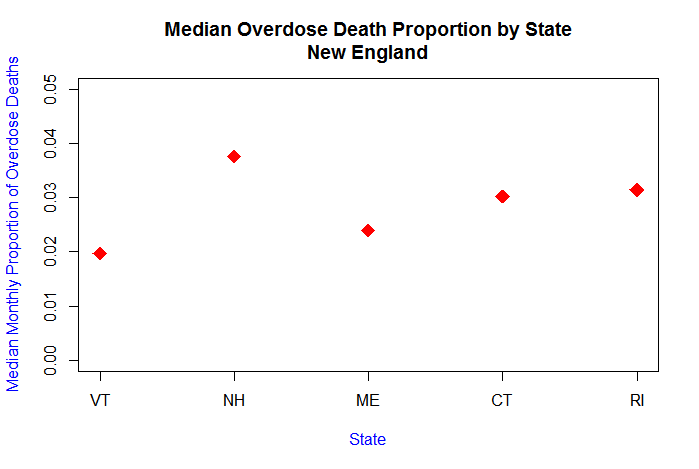

Copy and paste the code you used to complete this exercise into the file you submit along with the generated plot.

## The `barplot` Function

Another common approach to plotting a continuous variable and a categorical variable is through use of a horizontal or vertical bar plot. The `barplot` function accepts many of the same arguments as the `plot` function.

```r
barplot(nodne,
        main="Average Monthly Count of Overdose Deaths by State\nNew England",
        xlab="State",
        ylab="Average Monthly Count of Overdose Deaths",
        col = "forestgreen",
        ylim = c(0,1000),
        width = 0.4,
        space = 0.4,
        xlim = c(0,3))
 box()
```

We included several `plot` arguments that functioned identical to the same arguments when used in the `plot` function. New arguments include `width` and `space`, which are used to control bar width and spacing relative to the x-axis (limits must be specified). Converting the vertical bar plot above to a horizontal one is easy. Simply include an argument `horiz = TRUE`. You will also want to switch the x and y arguments.

```r
barplot(nodne,
        main="Average Monthly Count of Overdose Deaths by State\nNew England",
        ylab="State",
        xlab="Average Monthly Count of Overdose Deaths",
        col = "forestgreen",
        xlim = c(0,1000),
        width = 0.4,
        space = 0.4,
        ylim = c(0,3),
        horiz = TRUE)
 box()
```

**Exercise 3**

Choose one of the following continuous variables

- `NUMBER_COCAINE_DEATHS`
- `NUMBER_HEROIN_DEATHS`
- `NUMBER_PSYCHOSTIMULANT_DEATHS`

and create a new variable consisting of the proportion these deaths constitute from the overall number of deaths within a state and month (divide by `NUMBER_DEATHS`). Then create a horizontal bar chart depicting the mean of this newly created variable among individuals in (1) Washington DC (`DC`), (2) Maryland (`MD`), and (3) Virginia (`VA`). Label the bar plot and both axes appropriately.

Copy and paste the code you used to complete this exercise into the file you submit along with the generated plot.

In some instances we are interested in displaying values or statistics from a continuous variable by more than one categorical variables. For instance, what if we were interested in mean proportion of methadone oversdose deaths in 2015, 2016 and 2017 in states in New England versus states in the DC Area (Washington DC, Virgina, and Maryland). The `barplot` function can accommodate this extra layer of information by creating something known as a *grouped barplot*.

In order to use this functionality, we need to first calculate the desired means and then place them into a matrix that can be provided to the `barplot` function. The matrix should contain the values to be plotted and should be formatted in a very specific way in order that the grouping and adjacency of bars is as desired.

First, let’s create a data set containing mean proportion of methadone overdose deaths by Year and state location (New England vs. DC Area):

```r
library(dplyr)
```

```r
nd <- ods %>%
      mutate(LOCATION = 1*(STATE %in% c('CT','ME','VT','NH','MA','RI')) + 2*(STATE %in% c('DC','VA','MD')),
             DEATH_PROP_METHADONE = NUMBER_METHADONE_DEATHS/NUMBER_DEATHS) %>%
      filter(YEAR %in% c(2015,2016,2017), LOCATION %in% c(1,2)) %>%
      group_by(LOCATION,YEAR) %>%
      summarize(AVGMETH = mean(DEATH_PROP_METHADONE))

nd
```

Next, let’s convert this list object to a matrix.

```r
md <- matrix(as.matrix(nd[,3]),nrow = 3,ncol = 2, byrow = FALSE)

colnames(md) <- c("New England","DC Area")
row.names(md) <- c("2015","2016","2017")

md
```

Using this matrix, we can now create our bar plot.

```r
 barplot(md,
         beside = TRUE,
         main = "Mean Proportion Methadone Overdose Deaths\nby Location and Year",
         xlab = "Location",
         ylab = "Mean Proportion Methadone Overdose Deaths",
         col = c("blue","forestgreen","violet"),
         ylim = c(0,0.004))
 box()
```

It is also important with grouped bar plots such as these to include a legend so that it is apparent what the different color bars represent.

```r
 barplot(md,
         beside = TRUE,
         main = "Mean Monthly Proportion Methodone Overdose Deaths\nby Location and Year",
         xlab = "Location",
         ylab = "Mean Monthly Proportion Methodone Overdose Deaths",
         col = c("blue","forestgreen","violet"),
         ylim = c(0,0.004))
 box()

legend("topleft", legend=c("2015","2016","2017"),
        bty="n",
        title = c("Year"),
        fill=c("blue","forestgreen","violet"))
```

Notice that in using the `legend` command above, we did not specify the x- and y-coordinates as done previously. R also accepts keywords which describe the general location for a legend to be placed. Acceptable key words include `bottomright`, `bottom`, `bottomleft`, `left`, `topleft`, `top`, `topright`, `right` and `center`. The argument `bty = “n”` instructs R not to draw a box around the legend.

**Exercise 4**

Using the `barplot` function, write the R code necessary to recreate the plot below.

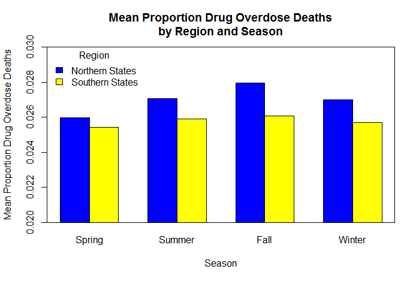

You will want to use the following in order to classify states according to region and to classifiy months according to season:

```
north <- c('CT', 'DC', 'MD', 'ME', 'NH', 'NY', 'OR', 'RI', 'VT', 'WA')
south <- c('NC', 'NM', 'NV', 'OK', 'SC', 'UT', 'VA', 'WV')

fall   <- c('September', 'October', 'November')
spring <- c('March', 'April', 'May')
winter <- c('December', 'January', 'February')
summer <- c('June', 'July', 'August')
```

You may also find the `xpd` argument useful (https://www.rdocumentation.org/packages/vcd/versions/0.1-3.5/topics/barplot).

The `barplot` function can also be used to create something known as a **stacked bar plot**. Stacked bar plots may be useful when exploring, for instance, what the count of methadone overdose deaths were in 2015, 2016, and 2017 in the DC Area and for each of these years, the relative counts within Washington DC, Virginia, and Maryland.

This can be accomplished using the following code:

```r
cd <- ods %>%
      filter(YEAR %in% c(2015,2016,2017), STATE %in% c('DC','MD','VA')) %>%
      group_by(STATE,YEAR) %>%
      summarize(SUMMETH = sum(NUMBER_METHADONE_DEATHS))

dd <- matrix(as.matrix(cd[,3]),nrow = 3,ncol = 3, byrow = TRUE)

colnames(dd) <- c("2015","2016","2017")
row.names(dd) <- c("DC","MD","VA")

dd

barplot(dd,
        main = "Count of Methadone Overdose Deaths by Year and State\nDC Area",
        xlab = "Year",
        ylab = "Count of Methadone Overdose Deaths",
        col = c("blue","forestgreen","violet"),
        ylim = c(0,4000),
        xlim = c(0,2),
        width = 0.4,
        space = 0.5)
 box()
 legend("topleft", c("DC","MD","VA"),
        bty="n",
        title = "State",
        fill=c("blue","forestgreen","violet"))
```

Notice that we are still supplying a matrix to the `barplot` function (same as when we requested the grouped bar plot). The major difference here is that we are not providing the `beside = TRUE` argument. When the `beside = TRUE` argument is omitted, R defaults to producing a stacked bar plot.

**Exercise 5**

Using the `barplot` function, write the R code necessary to recreate the plot below. Note that these are counts only within North Carolina (`STATE == NC`).

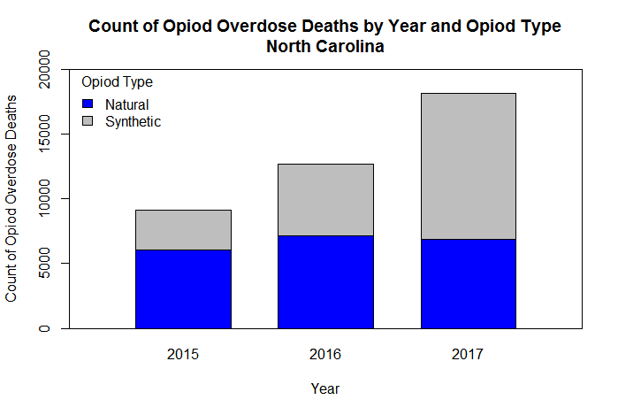

Copy and paste the code you used to complete this exercise into the file you submit along with the generated plot.

You are responsible for completing the 5 exercises described above and submitting them prior to 5:00PM on November 28th.